# Algorytmy danych geoprzestrzennych

Obliczenia geodezyjne

Krzysztof Dyba

## Jaki kształt ma Ziemia?

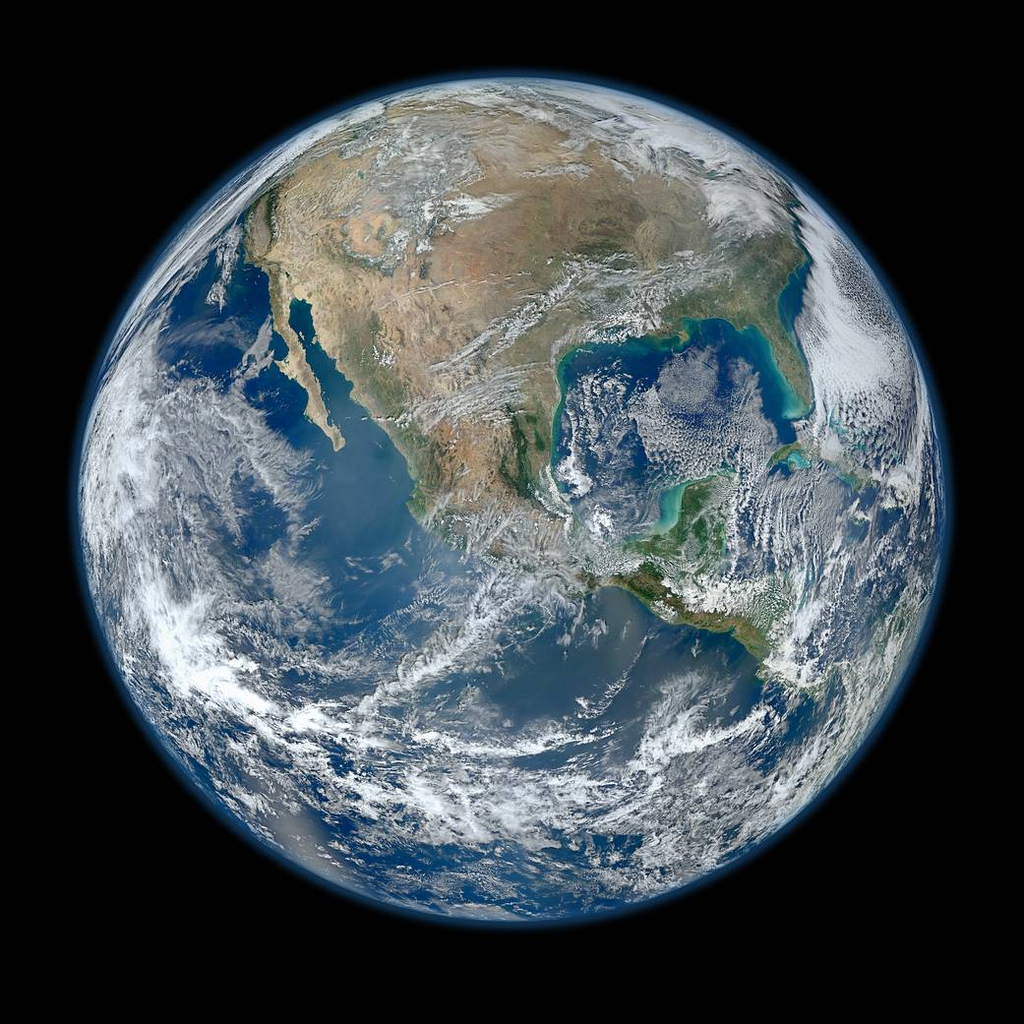

Blue Marble 2012, Suomi NPP

## Geoida

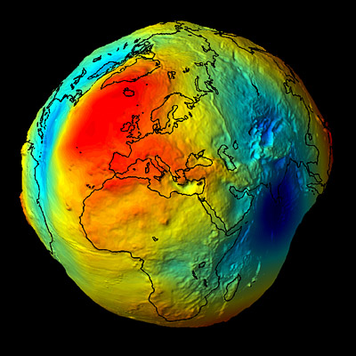

[International Centre for Global Earth Models](https://icgem.gfz-potsdam.de)

https://essd.copernicus.org/articles/11/647/2019/

## Geoida

**Geoida** to model kształtu Ziemi, który przedstawia złożoną, nieregularną powierzchnię, na którą siła grawitacji działa wszędzie prostopadle do powierzchni.

Geoida nie ma matematycznie zdefiniowanego kształtu. Jej kształt wynika z różnic w ziemskim polu grawitacyjnym spowodowanymi zmianami w gęstości i rozkładzie masy Ziemi (np. występowanie gór i dolin).

Źródłem danych zazwyczaj są satelitarne pomiary grawitacyjne (np. misja GRACE).

## Matematyczne reprezentacje

[figure not shown]

**Sfera** (góra)

**Elipsoida obrotowa** (lewo dół)

**Elipsoida** (prawo dół)

[Wikipedia](https://en.wikipedia.org/wiki/Ellipsoid)

## Elipsoida

**Elipsoida** to obiekt geometryczny, w którym wszystkie płaskie przekroje są elipsami lub okręgami. Wszystkie trzy osie mogą mieć różne długości.

## Elipsoida obrotowa (sferoida)

**Elipsoida obrotowa** to obiekt geometryczny utworzony przez obrót elipsy wokół jednej z jej osi. Jeśli elipsa zostanie obrócona wokół mniejszej osi, to w rezultacie powstanie elipsoida spłaszczona, która przypomina kształtem Ziemię.

Jest to szczególny przypadek elipsoidy, w której dwie z trzech osi są równe.

$$\frac{x^2 + y^2}{a^2} + \frac{z^2}{c^2} = 1$$

Jeśli:

$c < a$ – elipsoida spłaszczona

$c > a$ – elipsoida wydłużona

## Sfera

**Sfera** to idealnie okrągły obiekt geometryczny, w którym każdy punkt na powierzchni jest w równej odległości od środka. Jest to podstawowe i ogólne przybliżenie kształtu Ziemi, ponieważ nie uwzględnia spłaszczenia na biegunach.

Jest to szczególny przypadek elipsoidy, w której wszystkie trzy osie mają równą długość.

$$x^2 + y^2 + z^2 = r^2$$

## Obrazowanie Ziemi na mapie

**Problem**

Przedstawienie Ziemi na mapie obejmuje rzutowanie trójwymiarowego kształtu na dwuwymiarową powierzchnię. Ponieważ powierzchnia Ziemi jest zaokrąglona, proces ten wprowadza zniekształcenia związane ze kształtem, powierzchnią, odległością czy kierunkiem.

**Jakie jest rozwiązanie?**

## Odwzorowanie kartograficzne

**Odwzorowanie kartograficzne** to matematyczna transformacja szerokości i długości geograficznej z powierzchni sfery lub elipsoidy na płaszczyznę.

**Podstawowe typy odwzorowań:**

- Walcowe – Ziemia rzutowana jest na cylinder, który następnie jest rozwijany tworząc płaską mapę.
- Stożkowe – Ziemia rzutowana jest na stożek, który również jest rozwijany.
- Azymutalne (płaszczyznowe) – Ziemia rzutowana jest na płaską płaszczyznę, wyśrodkowaną w określonym punkcie.

## Przykład

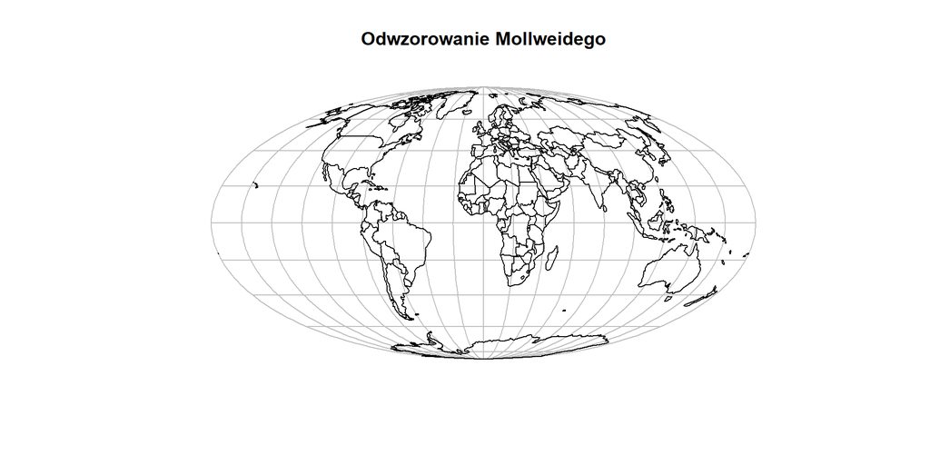

## Przykład

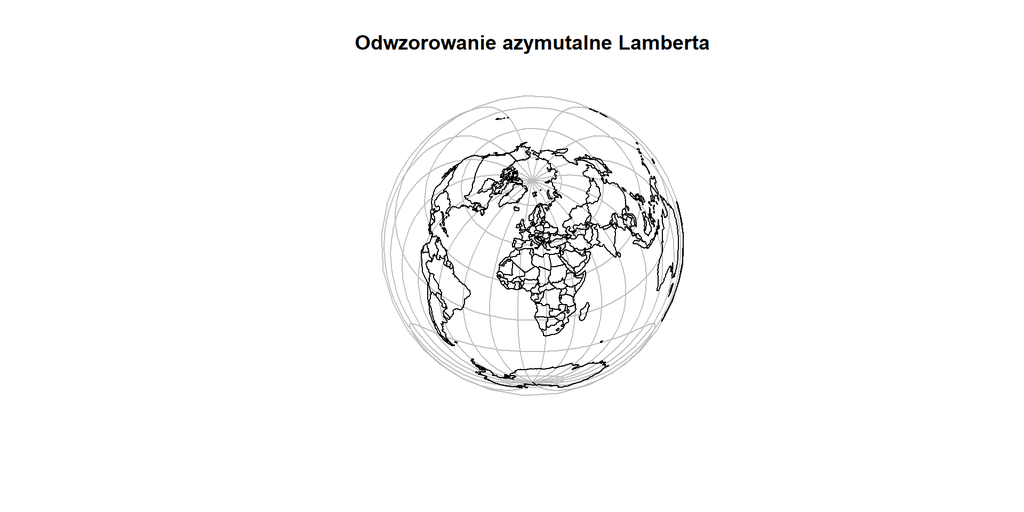

[**Więcej przykładów**](https://proj.org/en/latest/operations/projections/all_images.html)

## Elipsa Tissota

**Elipsa (wskaźnik) Tissota** to matematyczna koncepcja używana w kartografii do opisu zniekształcenia kształtów i rozmiarów, które występuje podczas odwzorowania zakrzywionej powierzchni Ziemi na mapie.

Została opracowana przez francuskiego matematyka Nicolasa Auguste’a Tissota w XIX wieku.

## Elipsa Tissota

W idealnym odwzorowaniu wskaźnik byłby okręgiem, wskazującym, że kształt i rozmiar obszaru są zachowane. Jednakże, w rzeczywistości wskaźniki te przyjmują kształt elips o różnych rozmiarach i orientacjach, w szczególności:

- jeśli oś wielka i mała elipsy nie są równe, to występuje zniekształcenie kształtu,
- jeśli rozmiar elipsy różni się od oryginalnego okręgu, to występuje zniekształcenie skali,
- jeśli osie elipsy nie są prostopadłe, to występuje zniekształcenie kątów (rotacja).

## Elipsa Tissota

Odwzorowanie Mercatora

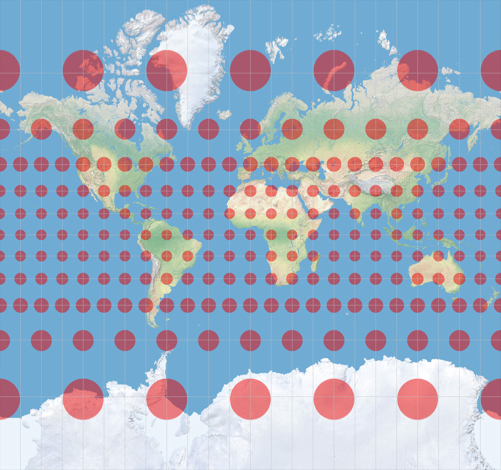

Tobias Jung ([Compare Map Projections](https://map-projections.net))

## Wnioski

- Przedstawianie Ziemi na mapie to skomplikowany proces wymagający kompromisów.
- Każde odwzorowanie powoduje pewne zniekształcenia.
- Różne cele wymagają odmiennych podejść.
- Odwzorowanie jest zawsze przybliżeniem rzeczywistości.

## Współrzędne geograficzne

## Współrzędne geograficzne

**Współrzędne geograficzne** to zestaw dwóch liczb (szerokości i długości geograficznej) służący do określenia położenia punktu na powierzchni Ziemi. Mierzone są w stopniach, które są jednostkami miary kątowej.

Szerokość geograficzna ($ϕ$) określa, jak daleko na północ (N) lub południe (S) znajduje się lokalizacja od równika. Zakres od 0° na równiku do 90° na biegunach.

Długość geograficzna ($λ$) określa, jak daleko na wschód (E) lub zachód (W) znajduje się lokalizacja od południka zerowego. Zakres od 0° na południku zerowym do 180°.

## Format zapisu

Zazwyczaj podawane są w jednym z dwóch formatów:

1. Stopnie (°), minuty (‘) i sekundy (’’). Jeden stopień podzielony jest na 60 minut, a jedna minuta na 60 sekund. Przykładowo: 52°17’34” N, 16°44’08” E.
2. Stopnie dziesiętne. Przykładowo: 52,2927° N, 16,7355° E.

**Nie ma jednoznacznej reguły dotyczącej kolejności zapisu szerokości i długości geograficznej. W zależności od standardu mogą być różne!**

## Konwersja

**Konwersja stopni, minut i sekund na stopnie dziesiętne:**

$$\text{Stopnie dziesiętne} = \text{Stopnie} + \frac{\text{Minuty}}{60} + \frac{\text{Sekundy}}{3600}$$

**Konwersja stopni dziesiętnych na stopnie, minuty i sekundy:**

$$\text{Stopnie} = \text{int}(\text{Stopnie dziesiętne})$$

$$\text{Minuty} = \text{int}\left((\text{Stopnie dziesiętne} - \text{Stopnie}) \times 60\right)$$

$$\text{Sekundy} = \left((\text{Stopnie dziesiętne} - \text{Stopnie}) \times 60 - \text{Minuty}\right) \times 60$$

## Implementacja

```r
decimal_to_dms = function(decimal_degrees, is_lat) {
  if (isTRUE(is_lat)) {
    if (decimal_degrees >= 0) direction = "N"
    else direction = "S" }
  else {
    if (decimal_degrees >= 0) direction = "E"
    else direction = "W" }

  decimal_degrees = abs(decimal_degrees)
  degrees = as.integer(decimal_degrees)
  minutes = as.integer((decimal_degrees - degrees) * 60)
  seconds = ((decimal_degrees - degrees) * 60 - minutes) * 60
  seconds = round(seconds)
  result = paste0(degrees, "°", minutes, "'", seconds, "''", " ", direction)
  return(result)
}
```

```
decimal_to_dms(52.2927, is_lat = TRUE)
#> "52°17'34'' N"
decimal_to_dms(16.7355, is_lat = FALSE)
#> "16°44'8'' E"
```

## Implementacja

```r
dms_to_decimal = function(dms_string) {
  dms_string = gsub("°", " ", dms_string)
  dms_string = gsub("'", " ", dms_string)
  parts = unlist(strsplit(dms_string, " "))
  parts = parts[parts != ""]

  degrees = as.numeric(parts[1])
  minutes = as.numeric(parts[2])
  seconds = as.numeric(parts[3])
  direction = parts[4]

  decimal = degrees + (minutes / 60) + (seconds / 3600)
  decimal = round(decimal, 4)
  if (direction %in% c("S", "W")) decimal = -decimal
  return(decimal)
}
```

```
dms_to_decimal("52°17'34'' N")
#> 52.2928
dms_to_decimal("16°44'08'' E")
#> 16.7356
```

## Precyzja współrzędnych

[figure not shown]

https://xkcd.com/2170

## Płaska czy okrągła?

Wpływ kształtu Ziemi na wyniki analizy przestrzennej

## Odległość

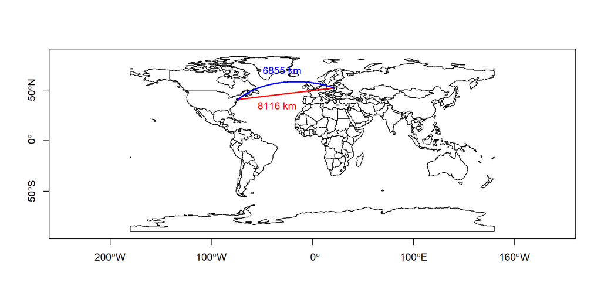

Odległość sferyczna: 6855 km

## Rodzaje odległości

1. Odległość euklidesowa.
2. Odległość sferyczna.
3. Odległość elipsoidalna.
4. Odległość powierzchniowa.

## Odległość euklidesowa

**Odległość euklidesowa** to miara odległości w linii prostej między dwoma punktami obliczana z następującego równania:

$$d = \sqrt{(\Delta x)^2+(\Delta y)^2} = \sqrt{(x_2 - x_1)^2 + (y_2 - y_1)^2}$$

Wynika ona bezpośrednio z twierdzenia Pitagorasa o trójkątach prostokątnych:

$$a^2 + b^2 = c^2$$

gdzie $a$ i $b$ to długość przyprostokątnych, a $c$ to długość przeciwprostokątnej.

## Odległość euklidesowa

[figure not shown]

[Wikipedia](https://commons.wikimedia.org/wiki/File:Euclidean_distance_2d.svg)

## Odległość sferyczna

**Odległość sferyczna** (ortodroma) to najkrótsza odległość między dwoma punktami na powierzchni sfery. Istnieje kilka sposobów na jej obliczenie, jednak dwa najistotniejsze to:

1. Sferyczne prawo cosinusów.
2. Wzór haversine.

[figure not shown]

[Wikipedia](https://commons.wikimedia.org/wiki/File:Ortodroma.svg)

## Sferyczne prawo cosinusów

$$\Delta\sigma = \arccos\left(\sin(\phi_1)\sin(\phi_2) + \cos(\phi_1)\cos(\phi_2)\cos(\lambda_2 - \lambda_1)\right)$$

$$d = r \cdot \Delta\sigma,$$
gdzie:

$\Delta\sigma$ to kąt środkowy między punktami na sferze,

$r$ to średnia długość promienia Ziemi wynosząca 6371,009 km.

## Wzór haversine

$$a = \sin^2\left(\frac{\Delta\phi}{2}\right) + \cos (\phi_1) \cos (\phi_2) \sin^2\left(\frac{\Delta\lambda}{2}\right)$$

$$c = 2 \cdot \operatorname{atan2}\left(\sqrt{a}, \sqrt{1-a}\right)$$

$$d = r \cdot c,$$

gdzie:

$\Delta\lambda = \lambda_2 - \lambda_1$ (różnica w odległości geograficznej),

$\Delta\phi = \phi_2 - \phi_1$ (różnica w szerokości geograficznej),

$r$ to średnia długość promienia Ziemi wynosząca 6371,009 km.

## Odległość elipsoidalna

**Odległość elipsoidalna** to najkrótsza odległość między dwoma punktami na powierzchni elipsoidy. Jej obliczenie jest złożonym zadaniem i obejmuje rozwiązanie zestawu równań nieliniowych.

Najczęściej stosowaną metodą jest opracowana przez polsko-amerykańskiego geodetę Thaddeusa Vincenty’ego w 1975 r. Jednak, ograniczeniem mogą być problemy ze zbieżnością w przeciwległych punktach.

W przypadku zastosowań wymagających najwyższej precyzji stosuje się algorytm Karneya (2013 r.) uważany za najdokładniejszą metodę.

## Odległość powierzchniowa

**Odległość powierzchniowa** to rzeczywista odległość mierzona wzdłuż powierzchni terenu, uwzględniająca zmiany wysokości i nierówności powierzchni. Inaczej nazywana jest pomiarem trójwymiarowym (X, Y, Z). Do wyliczenia niezbędny jest numeryczny model terenu.

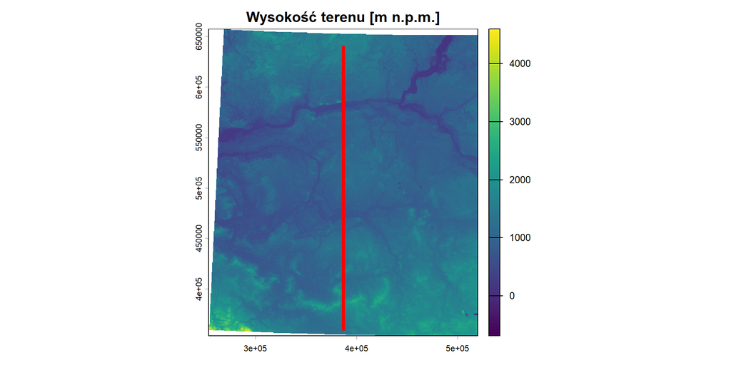

## Odległość powierzchniowa

1. Wyodrębnij wartości wysokości terenu wzdłuż linii.
2. Oblicz skumulowaną odległość euklidesową w trzech wymiarach (X, Y, Z) między kolejnymi punktami.

```r
points = extract(r, line, xy = TRUE)

total_length = 0
for (i in 2:nrow(points)) {
  p1 = c(points$X[i - 1], points$Y[i - 1], points$Z[i - 1])
  p2 = c(points$X[i], points$Y[i], points$Z[i])
  distance = sqrt(sum((p2 - p1)^2))
  total_length = total_length + distance
}

print(total_length)
```

## Odległość powierzchniowa

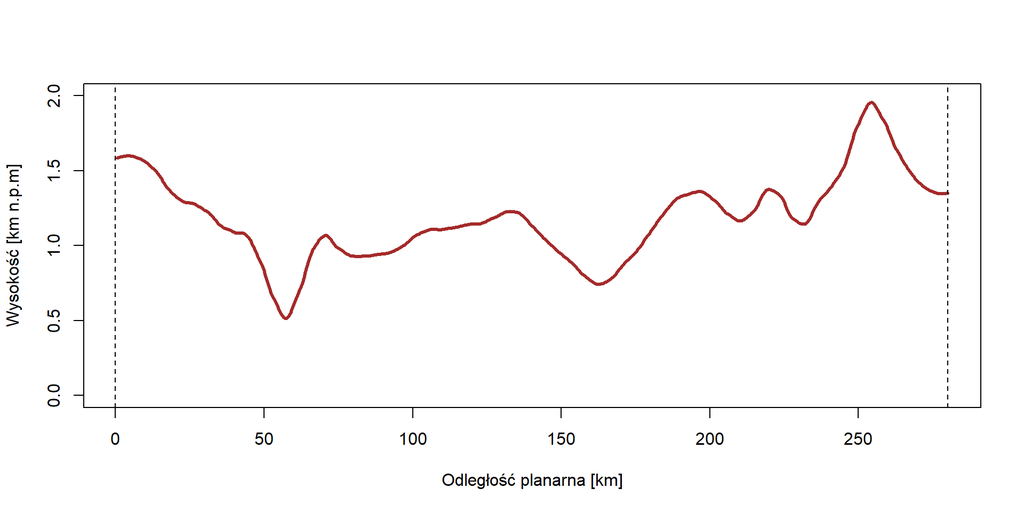

Odległość planarna: 280 km

Odległość powierzchniowa: 283 km

## Powierzchnia poligonów

**Który z przedstawionych obszarów jest większy?**

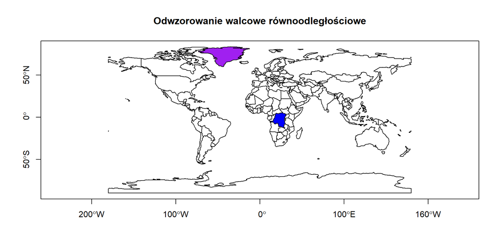

Powierzchnia:

- Grenlandia: 2 166 086 km$^2$
- Demokratyczna Republika Konga: 2 345 409 km$^2$

## Powierzchnia poligonów

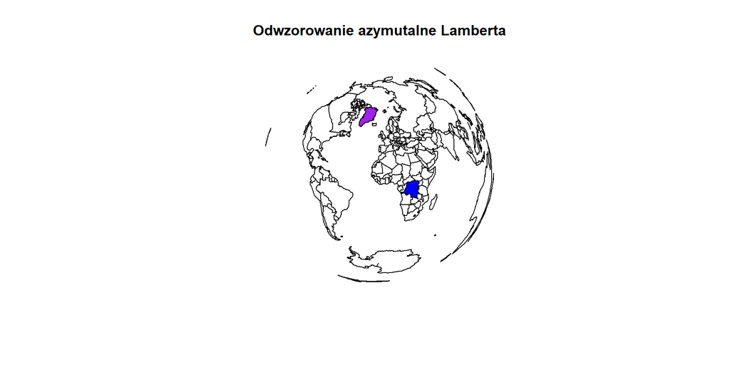

## Powierzchnia poligonów

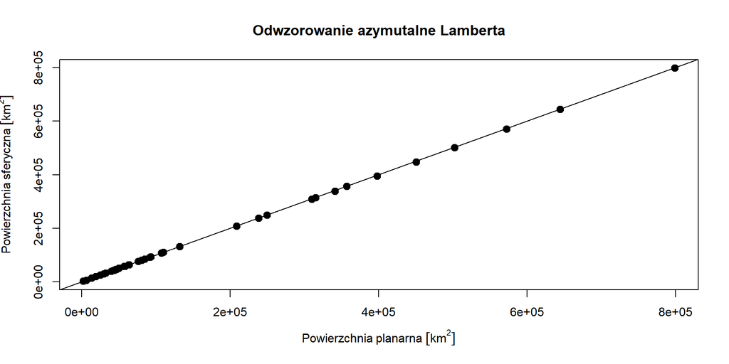

Każda kropka reprezentuje jeden kraj europejski.

## Powierzchnia poligonów

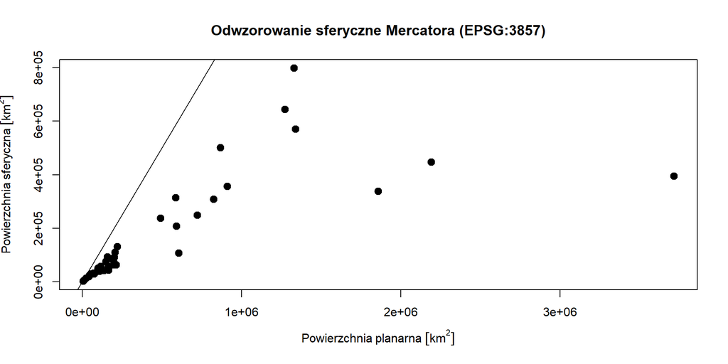

## Rzeczywisty rozmiar komórek

```r
r = rast(xmin = 150000, ymin = 120000, xmax = 880000, ymax = 810000,
         resolution = 1000, crs = "EPSG:2180")
res(r)[1] * res(r)[2]
```

```
#> 1 000 000
```

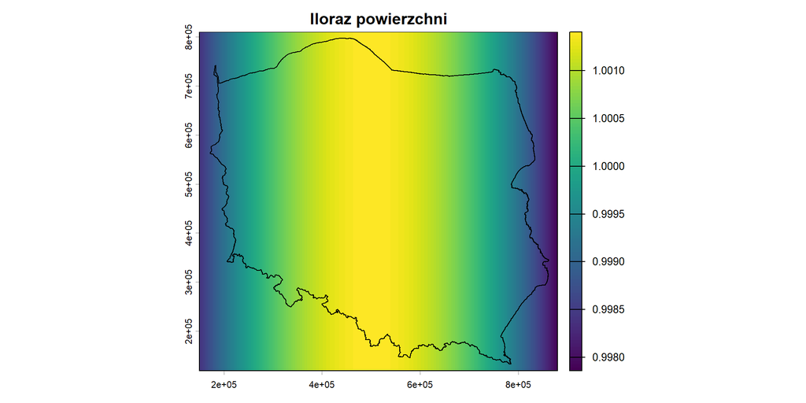

**Średnia powierzchnia komórek na sferze:** 1 000 307 m$^2$

## Porównanie modeli

|  | Kartezjański | Elipsoidalny |
| --- | --- | --- |
| Model Ziemi | Płaszczyzna | Elipsoida |
| Współrzędne | Metryczne | Geograficzne |
| Dokładność | Umiarkowana (ignorowana krzywizna) | Wysoka |
| Złożoność | Mniejsza | Większa |
| Przeznaczenie | Mała skala (lokalna) | Duża skala (globalna) |